### ECE/CS/ISyE 524 — Introduction to Optimization — Spring 2022

# Employee Shift Scheduling at a Hospital

#### Nitin Saxena (nitin.saxena@wisc.edu), Sambhav Satija (ssatija@wisc.edu), Gowtham Senthilkumar (gsenthilkum2@wisc.edu)

1. Introduction
2. Mathematical Model - Model 1 (Baseline))
3. Model 1 (Baseline))
   1. Data
   2. Inputs
   3. Implementation
   4. Observations
4. Model 2
   1. Adding Real World Constraints
   2. Implementation
   3. Observations
5. Model 3
   1. Making the Schedule Fair to all Employees
   2. Implementation
   3. Observations
6. Making it Practical
7. Discussion
8. Conclusion
9. Author Contributions

## 1. Introduction

Employee Scheduling is a common problem in various industries which work round the clock. Examples of such industries include Emergency Services like Fire Fighting Services, Power Generation, Police, Hospitals, etc. Such organizations need a scheduling system in place that ensures service delivery to their customers 24*7.

In this project, we focus on solving the shift scheduling problem for Hospitals. The fundamental role of medical facilities is to be consistently available to their patients. The **effective scheduling** of their employees' shifts is important

- to find a feasible solution that satisfies all practical constraints that arise of irregular working hours.
- to maximize Patient Satisfaction
- to maximize Employee (Doctors and Nurses) Satisfaction
- to fulfill Business Requirements

Shift Scheduling System needs to factor in several constraints that arise out of practical considerations. These include Employee availability for unusual working hours such as night shifts and weekends. An ideal system should take into account the long term sustainability of the recommendations. It must be modelled considering sleep cycles of employees and ensuring weekly scheduled offs, while at the same time meeting the needs of the business.

[History](https://en.wikipedia.org/wiki/Nurse_scheduling_problem) of Nurse Scheduling Problem

[figure not shown]

#### Goals:

1. Design an Employee Shift Scheduling system as an optimization Problem with the objective of maximizing the employee choices while meeting the business requirements and practical constraints arising out of shift scheduling.
2. Incorporate real-world constraints for a realistic solution.
3. Compare different modelling strategies

## 2. Mathematical Model - Model 1 (Baseline)

The scheduling problem in a medical facility strives to ensure a good doctor-to-patient ratio. We attempt to break down the messy scheduling requirements into concise, yet comprehensive, real-world constraints.

**Doctors:** To begin, we assume that our facility manages $n$ doctors. We recognize the need for different categories/levels of doctors and assume 3 categories:

1. Senior *(Sen)*
2. Mid *(Mid)*
3. Junior *(Jun)*

Our categorization is flexible enough to be further broken down into general surgeons, anesthesiologists, radiologists or more.

**Shifts:** Based off one group member's familiarity with the medicine infrastructure in their country, we consider a 3-shift cycle:

1. Morning *(M)*
2. Evening *(E)*
3. Night *(N)*

**Varying needs per shift:** Patient traffic waxes and wanes (mostly) predictably. Thus, the facility should be able to provide some guarantees on the number of medical staff present.

### Setup

Our facility needs to schedule $m$ shifts in the presence of $n$ doctors.

**Inputs:**

- A preference matrix $P$ obtained from employees, containing every employee's preferences for a particular future shift. \ The preference is ranked on a *scale of 0 to 3*, with 3 being the highest preference.

$$ Preferences , P \in \mathbb{R}^ {nxm}\\ P_{i,j} \in \{0,1,2,3\} \\ P_{i,j} = 0 \text{ signifies that employee i is not available for shift j} $$

- A business-driven requirement ($m$ x $||T||$) matrix $R$, containing minimum requirements on the number of each type of doctor that must be present during a shift. Here, $T = \{Senior, Mid, Junior\}$

$$ Requirements, R \in \mathbb{Z}^{mxC}\\ C = ||T|| = No. \ of \ Categories\\ \mathbb{Z} = Non \ Negative \ Integers $$

### Decision Variables

$A$ is ($n$ x $m$) matrix of **binary variables** that defines whether a certain doctor is assigned a certain shift:

$$ A \in \mathbb{Z}^{nxm}\\ $$$$ A_{n,m} = \begin{pmatrix} a_{1,1} & a_{1,2} & \cdots & a_{1,m} \\ a_{2,1} & a_{2,2} & \cdots & a_{2,m} \\ \vdots & \vdots & \ddots & \vdots \\ a_{n,1} & a_{n,2} & \cdots & a_{n,m} \end{pmatrix} $$$$ A_{i,j} \in \begin{cases} 1 & \text{$i^{th}$ doctor scheduled for $j^{th}$ shift} \\ 0 & \text{otherwise} \end{cases} $$

### Objective

In an effort to maximize the overall workplace happiness, we maximize the preference-weighted sum of all allotments in the schedule.

$$ \begin{aligned} \underset{A \in \mathbb{0,1}}{\text{Maximize}}\qquad& \sum_{i=1}^n \sum_{j=1}^m A_{ij}*P_{ij} \\ \end{aligned} $$

### Constraints

1. One employee assigned to only one shift per day $$ \sum_{j}^{j+2} A_{ij} \leq 1 \quad \forall i \in \{1,2,..n\}, \quad \forall j \in \{1,4,7...m\} $$
2. Category requirements are met for all categories and shifts $$ \sum_{i=1}^n A_{ij}*M_{ic} \geq R_{jc} \quad \forall j \in \{1,2,...m\}, \quad \forall c \in \{1,2,..C\}\\ R_{jc} = \text{Requirement of category c for shift j} $$

$$ \text{Mask, } M_{i,c} \in \begin{cases} 1 & \text{$i^{th}$ doctor belongs to $c^{th}$ category} \\ 0 & \text{otherwise} \end{cases} $$

1. If employee is not available for any shift, then don't assign them that shift. $$ \text{If} \ P_{ij} = 0, \text{then} \ A_{ij} = 0 $$ $$ A_{ij} \leq P_{i,j} $$

## 3. Model 1 (Baseline)

### 3.A. Data

Publicly available datasets for the shift scheduling problem, in particular employees availability and preferences, are hard to acquire since it contains employee's personal information. Moreover, the dataset is not particulary important as the model has to be robust enough to tackle any variation in these inputs. Still we try to simulate the data as close to the real use case as possible. One of our team-members had experience working in a shift-scheduling setup. From their experience, some of the commong observations related to preferences are -

- Probability of Preference to work on weekdays is higher than that of weekends.
- Probability of Preference to work in day shifts (Morning and Evening) is higher than that of night shifts.
- Probability of Preference for Morning and Evening are almost uniformly distributed.

These Observations also matches with our intuition and are a good starting point to test our model. Although, these can be modified as per situation.

**Generating data from insights:**

We needed to convert these observations into the form of a Preference Matrix. We decided to use Beta Distribution to simulate probabilistic rules of preferences. Creating a probabilistic preference generator is vital as it can be used to test against a multitude of possible scenarios while providing a realistic representation of the on-ground preference.

```julia
# import Pkg;
# Pkg.add("Distributions");
```

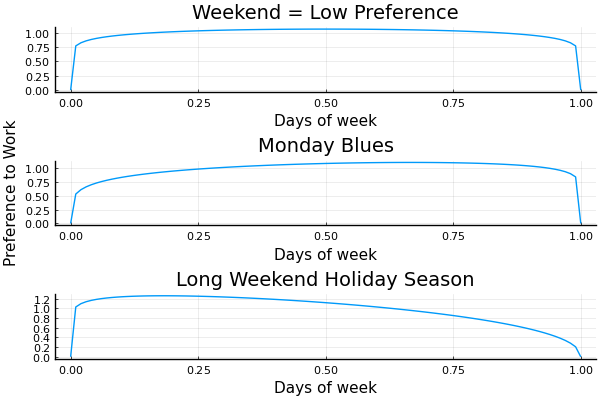

```julia
# We find parameters for a β distribution s.t.
# the distribution resembles the probability of preference to work on a given day.

# Some Sample Distributions
using Distributions
using Plots
Plots.pyplot()

xx = range(0,stop=1.0,length=100);
d1 = Beta(1.1, 1.1)
p1 = plot(plot(xx,pdf.(d1,xx)),
    legend=false, ticks=true,
    xlabel="Days of week",
    title = "Weekend = Low Preference");


d2 = Beta(1.2, 1.1)
p2 = plot(plot(xx,pdf.(d2,xx)),
    legend=false, ticks=true,
    xlabel="Days of week",
    ylabel="Preference to Work",
    title = "Monday Blues");


d3 = Beta(1.1, 1.45)
p3 = plot(plot(xx,pdf.(d3,xx)),
    legend=false, ticks=true,
    xlabel="Days of week",
    title = "Long Weekend Holiday Season");


plot(p1, p2, p3, layout=(3,1))
```

We then build a simple generator which randomly creates a preference matrix given a beta distribution. This can be found further down in the implementation. Adding similar preference rules for day/night shifts is left for future work. However, we do tackle shift timing consequences in our constraints.

### 3.B. Inputs

```julia
# Defining the Input Parameters

#Defining Number of Doctors in each Doctor category
d_s = 5 #Senior
d_m = 10 #Mid
d_j = 15 #Junior

#Total Number of Employees
n = d_s + d_m + d_j

#No of Shifts
weeks = 2
n_days = weeks*7
m = n_days*3;
Shifts = [:M,:E,:N];


# Categorization: masking
no_categories = 3

mask_categories = Int.(zeros(n, no_categories))
mask_categories[1:d_s, 1] .= 1
mask_categories[d_s+1:d_s+d_m, 2] .= 1
mask_categories[d_s+d_m+1:n, 3] .= 1

mask_categories;
```

```julia
#Data Generation for Doctor Availabilities and Shift Requirements

#Requirement Matrix define the required number of each category in a shift
# Simulating Requirements so as we have enough employees for the constraints

req_seniors = [floor(d_s/5) for i in 1:m] #randn(m, 1) * (d_s / 4)
req_mid = [floor(d_m/5) for i in 1:m] # randn(m, 1) * (d_m / 4)
req_juniors = [floor(d_j/5) for i in 1:m] # randn(m, 1) * (d_j / 4)

R = round.([req_seniors req_mid req_juniors]);
```

```julia
#Preference Matrix which is used to generate Doctors' Preferences for particular shifts
# P = round.(rand(n,m)*3); We originally used to generate preferences with uniform randomness.

using Distributions
function generatePreferenceMatrixSingleWeek(α, β)
    d = Beta(α, β)
    sampled_distribution = rand(d, 10000)

    boxes = [0, 0, 0, 0, 0, 0, 0] # for each workday.
    box_idxs = Dict()
    for i in 1:7
        box_idxs[i] = [(i-1)/7, i/7]
    end

    for i = 1:length(sampled_distribution)
        for (box_idx, bounds) in box_idxs
            if sampled_distribution[i] >= bounds[1] && sampled_distribution[i] <= bounds[2]
                boxes[box_idx] += 1
            end
        end
    end

    # this gives us the approximate probability of people wanting to take a holiday.
    # We assume that at peaks (weekends, holidays), around 75% of people want to take
    # a vacation.
    upper = trunc(Int, maximum(boxes) * 4/3 + 1)
    prob_1 = [x/upper for x = boxes]
    prob_2 = [prob_1[i] + 0.15 for i = 1:length(boxes)]
    prob_3 = [1 for i = 1:length(boxes)]

    r = rand(n,7*3)
    for i in 1:n # i_th doctor
        for d in 1:7 # weekday
            for s in 1:3 # shift of that same day
                j = s + (d-1)*3
                x = r[i, j]
                if x <= prob_1[d]
                    r[i, j] = 1
                elseif x >= prob_1[d] && x <= prob_2[d]
                    r[i, j] = 2
                else
                    r[i, j] = 3
                end
            end
        end
    end
    return r
end

function generatePreferenceMatrix()
    preference = generatePreferenceMatrixSingleWeek(0.7, 0.45)
    for i = 2:weeks
       preference = hcat(preference, generatePreferenceMatrixSingleWeek(0.7, 0.45))
    end
    return preference
end

P = generatePreferenceMatrix();
```

### 3.C. Implementation

```julia
using JuMP, Cbc, GLPK, NamedArrays

hospital = Model(with_optimizer(GLPK.Optimizer))

N = collect(1:n)
M = collect(1:m)
C = collect(1:no_categories)
@variable(hospital, 0<= A[N,M] <= 1)#, Bin)

# Maximimize overall employment satisfaction.
@objective(hospital, Max, sum(A.*P) )

# Only One shift per day per doctor
@constraint(hospital, c1[shift in 1:3:m, emp in N], sum(A[emp,shift:shift+2]) <= 1)

# Category Requirements Constraint
@constraint(hospital, c2[shift in M, cat in C],
    sum(A[emp,shift] .* mask_categories[emp, cat] for emp in N) >= R[shift,cat])

#Assign shift to employee only if the employee is available
@constraint(hospital, c3, A.<= P )

optimize!(hospital)
println("Our solution is ", termination_status(hospital))
println()

# Solution
#a = round.(Int,value.(A).data)
a = value.(A).data
S = Vector{Symbol}()
for i in 1:n_days
    push!(S, Symbol("M", i))
    push!(S, Symbol("E", i))
    push!(S, Symbol("N", i))
end
println()
NamedArray(a, (N,S))
```

```
Our solution is OPTIMAL
```

```
30×42 Named Matrix{Float64}
A ╲ B │  :M1   :E1   :N1   :M2   :E2  …  :E13  :N13  :M14  :E14  :N14
──────┼──────────────────────────────────────────────────────────────
1     │  1.0   0.0   0.0   1.0   0.0  …   0.0   0.0   1.0   0.0   0.0
2     │  0.0   0.0   1.0   0.0   0.0      0.0   1.0   0.0   1.0   0.0
3     │  0.0   0.0   1.0   0.0   0.0      1.0   0.0   0.0   0.0   1.0
4     │  1.0   0.0   0.0   1.0   0.0      1.0   0.0   1.0   0.0   0.0
5     │  0.0   1.0   0.0   0.0   1.0      0.0   0.0   1.0   0.0   0.0
6     │  1.0   0.0   0.0   1.0   0.0      0.0   0.0   1.0   0.0   0.0
7     │  0.0   1.0   0.0   1.0   0.0      0.0   0.0   0.0   1.0   0.0
8     │  0.0   0.0   1.0   0.0   1.0      0.0   1.0   0.0   0.0   1.0
9     │  0.0   1.0   0.0   0.0   1.0      1.0   0.0   0.0   1.0   0.0
10    │  0.0   0.0   1.0   0.0   0.0      0.0   1.0   0.0   0.0   1.0
11    │  0.0   0.0   1.0   0.0   0.0      0.0   1.0   0.0   0.0   1.0
⋮          ⋮     ⋮     ⋮     ⋮     ⋮  ⋱     ⋮     ⋮     ⋮     ⋮     ⋮
20    │  0.0   1.0   0.0   0.0   1.0      0.0   1.0   0.0   1.0   0.0
21    │  1.0   0.0   0.0   0.0   1.0      1.0   0.0   0.0   1.0   0.0
22    │  0.0   1.0   0.0   1.0   0.0      0.0   0.0   0.0   0.0   1.0
23    │  0.0   0.0   1.0   0.0   0.0      0.0   0.0   1.0   0.0   0.0
24    │  1.0   0.0   0.0   0.0   0.0      0.0   0.0   0.0   0.0   1.0
25    │  0.0   1.0   0.0   0.0   0.0      0.0   0.0   0.0   1.0   0.0
26    │  1.0   0.0   0.0   1.0   0.0      0.0   0.0   1.0   0.0   0.0
27    │  1.0   0.0   0.0   1.0   0.0      0.0   1.0   1.0   0.0   0.0
28    │  1.0   0.0   0.0   1.0   0.0      0.0   1.0   0.0   1.0   0.0
29    │  1.0   0.0   0.0   1.0   0.0      1.0   0.0   1.0   0.0   0.0
30    │  1.0   0.0   0.0   1.0   0.0  …   0.0   0.0   1.0   0.0   0.0
```

### 3.D. Observations

Model 1 yields the schedule for the employees without using Binary Variables. We may get integer solutions without explicitly modeling the problem for binary variables as the incidence matrix is totally unimodular.

Observations- We get integer solutions without explicitly modeling the problem for binary variables if all the constraints are satisfied for integer solutions. For example, if the employee strength is enough to cater to all category requirements, we get integer solutions. Else, Model may 'split' the employee into two shifts and we get fractional solutions. To avoid that, we may need to use Binary Variables.

Moreover, real world behaviour is more complex than this basic model. As of now, our model satisfies only these basic constraints-

c1 - Only one shift per day per employee should be allowed \ c2 - Category Requirements should be met for all categories else model should highlight infeasibility. \ c3 - An Employee must be assigned to a shift only if they are available.

We need to add more constraints to make the model close to real world scenario. We may need to model the variables explicitly as Binary Variables as we add more constraints.

## 4. Model 2

### 4.A. Adding Real World Constraints

Based on our personal experiences of working in the industry, we came up with a list of real world constraints that a schedule should adhere to.

c4 - Weekly Working Hour Limit should be followed for all employees.

$$ \sum_{j=1}^{m} 8 A_{ij} \leq \frac{m}{3} \times \frac{W}{7} \quad \forall i \in {1,2,...n}\\ W = \text{Weekly Working Hour Limit (e.g., W = 40 hrs/week)} $$

c5 - Ensure Employees get 2 days off in every 7 days.

$$ \sum_{j=s}^{s+o} A_{ij} \leq r-2 \quad \forall i \in {1,2,...n}, \quad \forall s \in {1,2,....m-o}\\ r = 7 \text{ (for 2 off days in every 7 days)}\\ o = 3r-1 $$

Minimize disruptions to the Circadian Rhythm

c6 - Sleep Cycle Constraint: Evening shift followed by Morning shift shouldn't be allowed.\

$$ A_{i,j} + A_{i,j+2} \leq 1 \quad \forall i \in {1,2,...n} , \quad \forall j \in {2,5,8,...m-2} $$

c7 - Sleep Cycle Constraint: Night shift followed by Morning or Evening shifts shouldn't be allowed.

$$ \sum_{j=s}^{s+2} A_{i,j}\leq 1 \quad \forall i \in {1,2,...n} , \quad \forall s \in {3,6,9,...m-3} $$

### 4.B. Implementation

```julia
using JuMP, GLPK, NamedArrays

hospital = Model(with_optimizer(GLPK.Optimizer))

N = collect(1:n)
M = collect(1:m)
C = collect(1:no_categories)

# max_work_hrs = 40 hrs per week
max_work_hrs_per_week = 50

@variable(hospital, 0<= A[N,M] <= 1, Bin)

# Maximimize overall employment satisfaction.
@objective(hospital, Max, sum(A.*P) )

# Only One shift per day per doctor
@constraint(hospital, c1[shift in 1:3:m, emp in N], sum(A[emp,shift:shift+2]) <= 1)

# Category Requirements Constraint
@constraint(hospital, c2[shift in M, cat in C],
    sum(A[emp,shift] .* mask_categories[emp, cat] for emp in N) >= R[shift,cat])

#Assign shift to employee only if the employee is available
@constraint(hospital, c3, A.<= P )

# Working Hours Constraints
@constraint(hospital, c4[emp in N], sum(A[emp,j] for j in M) <= (m/3)*(max_work_hrs_per_week/7)/8 )

#Ensure doctor gets 2 days off in every week (rota = 8 days)
rota = 8
off = rota*3-1
@constraint(hospital, c5[shift in 1:m-off, emp in N], sum(A[emp, shift:shift+off]) <= rota-2)

# Sleep Cycle - E followed by M not allowed
@constraint(hospital, c6[shift in 2:3:m-2, emp in N], A[emp,shift]+A[emp,shift+2]<=1 )

# Sleep Cycle - N followed by M,E not allowed
@constraint(hospital, c7[shift in 3:3:m-3, emp in N], sum(A[emp,shift:shift+2]) <= 1)


optimize!(hospital)
println("Our solution is ", termination_status(hospital))

# Solution
a = value.(A).data
S = Vector{Symbol}()
for i in 1:n_days
    push!(S, Symbol("M", i))
    push!(S, Symbol("E", i))
    push!(S, Symbol("N", i))
end
NamedArray(a, (N,S))
```

```
Our solution is OPTIMAL
```

```
30×42 Named Matrix{Float64}
A ╲ B │  :M1   :E1   :N1   :M2   :E2  …  :E13  :N13  :M14  :E14  :N14
──────┼──────────────────────────────────────────────────────────────
1     │  1.0   0.0   0.0   1.0   0.0  …   1.0   0.0   0.0   0.0   1.0
2     │  0.0   0.0   1.0   0.0   0.0      0.0   1.0   0.0   0.0   0.0
3     │  0.0   1.0   0.0   0.0   1.0      0.0   0.0   1.0   0.0   0.0
4     │  1.0   0.0   0.0   1.0   0.0      0.0   0.0   1.0   0.0   0.0
5     │  0.0   1.0   0.0   0.0   1.0      0.0   0.0   0.0   1.0   0.0
6     │  0.0   0.0   0.0   1.0   0.0      1.0   0.0   0.0   0.0   0.0
7     │  0.0   1.0   0.0   0.0   1.0      0.0   0.0   0.0   1.0   0.0
8     │  0.0   0.0   1.0   0.0   0.0      0.0   1.0   0.0   0.0   1.0
9     │  1.0   0.0   0.0   1.0   0.0      0.0   0.0   1.0   0.0   0.0
10    │  1.0   0.0   0.0   0.0   1.0      0.0   1.0   0.0   0.0   0.0
11    │  0.0   0.0   1.0   0.0   0.0      0.0   1.0   0.0   0.0   1.0
⋮          ⋮     ⋮     ⋮     ⋮     ⋮  ⋱     ⋮     ⋮     ⋮     ⋮     ⋮
20    │  1.0   0.0   0.0   0.0   1.0      0.0   0.0   0.0   1.0   0.0
21    │  1.0   0.0   0.0   0.0   1.0      1.0   0.0   0.0   0.0   1.0
22    │  0.0   1.0   0.0   0.0   1.0      1.0   0.0   0.0   1.0   0.0
23    │  0.0   0.0   1.0   0.0   0.0      0.0   0.0   1.0   0.0   0.0
24    │  1.0   0.0   0.0   0.0   1.0      0.0   0.0   0.0   0.0   1.0
25    │  0.0   1.0   0.0   0.0   0.0      0.0   0.0   0.0   1.0   0.0
26    │  1.0   0.0   0.0   1.0   0.0      0.0   0.0   1.0   0.0   0.0
27    │  1.0   0.0   0.0   1.0   0.0      0.0   1.0   0.0   0.0   1.0
28    │  1.0   0.0   0.0   1.0   0.0      0.0   0.0   0.0   1.0   0.0
29    │  1.0   0.0   0.0   0.0   0.0      0.0   0.0   0.0   0.0   1.0
30    │  1.0   0.0   0.0   1.0   0.0  …   0.0   1.0   0.0   0.0   1.0
```

### 4.C. Observations

One key observation from Model 2 is that the weekly cycle (7 day cycle) may not be feasible. When we try to implement the weekly off constraint with 2 offs in 7 days, the solution was infeasible. When we changed it to 2 offs in 8 days, the model found the solution.

Also, we experimented with other constraints, including max working hours per week. In some cases, relaxing the constraints allowed the model to find the optimal solution.

Essentially, its a trade-off between the number of employees and the constraint complexity. So, as we keep adding the constraints, the model becomes increasingly complex and becomes more suitable for larger organizations with more employees. The greater number of employees would cater to the increased requirements and constraints.

## 5. Model 3

### 5.A. Making the Schedule Fair to all Employees

Ensure Fair Distribution of undesirable shifts (e.g. Night shift or weekends )

Working 24*7 means doctors have to do night shifts, which are undesirable in long run due to various health related and social reasons. Employees attending night shifts face disturbed circadian rhythm and miss out on several social events the next day. Due to these reasons, it is imperative that night shifts are distributed fairly across all employees.

Although, exact distribution may not be possible due to several constraints. To tackle that, we incorporate a variable which defines the maximum allowed difference of total night shifts done between any two employees.

c8 - Distibute Shifts among Employees as uniformly as possible, so that undesirable shifts, such as Night Shifts are distributed uniformly.

$$ \sum_{n=1}^{m/3} A_{in} \leq \frac {\sum_{n=1}^{m/3} R_{nc}}{d_c} + \text{night_max_diff} \quad $$$$ \forall c \in \{1,2,.....C\} \\ \forall i \in \{1,2,...d_c\} \\ \text{n = night shifts}\\ d_c=\text{ No. of Doctors in Category c}\\ R_{nc} = \text{ Requirement of catergory c on night shift n} $$

night_max_diff = Maximum allowed difference between total number of night shifts attended between any two employees.

### 5.B. Implementation

```julia
using JuMP, GLPK, NamedArrays, MosekTools, Mosek, Cbc

#hospital = Model(with_optimizer(GLPK.Optimizer))
#hospital = Model(with_optimizer(Mosek.Optimizer,LOG=0))
hospital = Model(with_optimizer(Cbc.Optimizer, loglevel = 0))


N = collect(1:n)
M = collect(1:m)
C = collect(1:no_categories)

# max_work_hrs = 40 hrs per week
max_work_hrs_per_week = 50

@variable(hospital, 0<= A3[N,M] <= 1, Bin)

# Maximimize overall employment satisfaction.
@objective(hospital, Max, sum(A3.*P) )

# Only One shift per day per doctor
@constraint(hospital, c1[shift in 1:3:m, emp in N], sum(A3[emp,shift:shift+2]) <= 1)

# Category Requirements Constraint
@constraint(hospital, c2[shift in M, cat in C],
    sum(A3[emp,shift] .* mask_categories[emp, cat] for emp in N) >= R[shift,cat])

#Assign shift to employee only if the employee is available
@constraint(hospital, c3, A3.<= P )

# Working Hours Constraints
@constraint(hospital, c4[emp in N], sum(A3[emp,j] for j in M) <= (m/3)*(max_work_hrs_per_week/7)/8 )

#Ensure doctor gets 2 days off in every week (rota = 8 days)
rota = 10
off = rota*3-1
@constraint(hospital, c5[shift in 1:m-off, emp in N], sum(A3[emp, shift:shift+off]) <= rota-2)

# Sleep Cycle - E followed by M not allowed
@constraint(hospital, c6[shift in 2:3:m-2, emp in N], A3[emp,shift]+A3[emp,shift+2]<=1 )

# Sleep Cycle - N followed by M,E not allowed
@constraint(hospital, c7[shift in 3:3:m-3, emp in N], sum(A3[emp,shift:shift+2]) <= 1)

#Night Shift allotment fairness constraints

# Set max diff allowed for night shifts between any 2 employees
night_max_diff = 1

@constraint(hospital, c8s[sdoc in 1:d_s],
    sum(A3[sdoc,nshift] for nshift in 3:3:m) <= (sum(R[nshift,1] for nshift in 3:3:m))/d_s+night_max_diff)

@constraint(hospital, c8m[mdoc in d_s+1:d_s+d_m],
    sum(A3[mdoc,nshift] for nshift in 3:3:m) <= (sum(R[nshift,2] for nshift in 3:3:m))/d_m+night_max_diff)

@constraint(hospital, c8j[jdoc in d_s+d_m+1:d_s+d_m+d_j],
    sum(A3[jdoc,nshift] for nshift in 3:3:m) <= (sum(R[nshift,3] for nshift in 3:3:m))/d_j+night_max_diff)


optimize!(hospital)
println("Our solution is ", termination_status(hospital))

# Solution
a3 = value.(A3).data
S = Vector{Symbol}()
for i in 1:n_days
    push!(S, Symbol("M", i))
    push!(S, Symbol("E", i))
    push!(S, Symbol("N", i))
end
NamedArray(a, (N,S))
```

```
Our solution is OPTIMAL
```

```
30×42 Named Matrix{Float64}
A ╲ B │  :M1   :E1   :N1   :M2   :E2  …  :E13  :N13  :M14  :E14  :N14
──────┼──────────────────────────────────────────────────────────────
1     │  1.0   0.0   0.0   1.0   0.0  …   1.0   0.0   0.0   0.0   1.0
2     │  0.0   0.0   1.0   0.0   0.0      0.0   1.0   0.0   0.0   0.0
3     │  0.0   1.0   0.0   0.0   1.0      0.0   0.0   1.0   0.0   0.0
4     │  1.0   0.0   0.0   1.0   0.0      0.0   0.0   1.0   0.0   0.0
5     │  0.0   1.0   0.0   0.0   1.0      0.0   0.0   0.0   1.0   0.0
6     │  0.0   0.0   0.0   1.0   0.0      1.0   0.0   0.0   0.0   0.0
7     │  0.0   1.0   0.0   0.0   1.0      0.0   0.0   0.0   1.0   0.0
8     │  0.0   0.0   1.0   0.0   0.0      0.0   1.0   0.0   0.0   1.0
9     │  1.0   0.0   0.0   1.0   0.0      0.0   0.0   1.0   0.0   0.0
10    │  1.0   0.0   0.0   0.0   1.0      0.0   1.0   0.0   0.0   0.0
11    │  0.0   0.0   1.0   0.0   0.0      0.0   1.0   0.0   0.0   1.0
⋮          ⋮     ⋮     ⋮     ⋮     ⋮  ⋱     ⋮     ⋮     ⋮     ⋮     ⋮
20    │  1.0   0.0   0.0   0.0   1.0      0.0   0.0   0.0   1.0   0.0
21    │  1.0   0.0   0.0   0.0   1.0      1.0   0.0   0.0   0.0   1.0
22    │  0.0   1.0   0.0   0.0   1.0      1.0   0.0   0.0   1.0   0.0
23    │  0.0   0.0   1.0   0.0   0.0      0.0   0.0   1.0   0.0   0.0
24    │  1.0   0.0   0.0   0.0   1.0      0.0   0.0   0.0   0.0   1.0
25    │  0.0   1.0   0.0   0.0   0.0      0.0   0.0   0.0   1.0   0.0
26    │  1.0   0.0   0.0   1.0   0.0      0.0   0.0   1.0   0.0   0.0
27    │  1.0   0.0   0.0   1.0   0.0      0.0   1.0   0.0   0.0   1.0
28    │  1.0   0.0   0.0   1.0   0.0      0.0   0.0   0.0   1.0   0.0
29    │  1.0   0.0   0.0   0.0   0.0      0.0   0.0   0.0   0.0   1.0
30    │  1.0   0.0   0.0   1.0   0.0  …   0.0   1.0   0.0   0.0   1.0
```

### 5.C. Observations

Model 3 ensures a fair distribution of the night shifts among all the employees. Combining the Fairness Constraints with Category Requirements however, results in the model becoming Infeasible for the given employee strength and requirement matrix. To tackle this, a variable is introduced which controls the maximum allowed difference between total number of night shifts attended between any two employees. This ensures, we get a solution while still maintaining a decent degree of fairness. For example, difference of 1 night shift may be allowed.

## 7. Discussion

The Shift Scheduler Model is capable of handling multiple real world constraints. We tried our best to model it as close to real industry use as possible. After running the model for multiple scenarios, it became apparent that the shift scheduling optimization problem is an interplay between Employee Strength, Requirements and constraints. This is expected for any optimization problem. In particular to this problem instance, we can prioritize constraints for a given employee strength and requirement matrix. In practice, this can allow us to optimize number of employees for a given set of constraints and requirements.

We can also do sensitivity analysis for the different constraints and see how it affects our optimal solution. For example, we can modify the max work hours constraint to analyze the min number of hours required for the given setup. Or we could apply sensitivity analysis to, say, number of employees and see how the overall preferences are satisfied with increasing the number of employees. Based upon the industry requirement and setup, the model allows the user to experiment with various combinations.

## 8. Conclusion and Future Potential Work

A robust model of a sheduling system has been modeled, that is capable of high degrees of complexity based on complexity and size of the organization. Taking into account factors ranging from simple, logical ones to more nuanced and important human factors such as sleep cycles, the model strives to efficiently schedule a periodic roster for the client. The Model can be extended to include the following future potential work-

#### - Solving infeasibility using Double Shifts.

There are many situations in which required number of doctors may not be available. But, hospital needs to continue to cater to patients. In such scenario, model can be extended to include double shifts as a temporary solution. This essentially means selectively relaxing some constraints and is not too complicated to implement.

#### - Taking Shift patterns into account while choosing a solution.

There can be many solutions to the shift scheduling problem. We can prioritize solutions with a well defined pattern which repeats periodically as compared to random allotments. Periodic Schedules are predictable and help employees plan their activities better.

#### - Minimize Changes to already existing Schedule.

In case of any unforeseen changes in the availability or requirements, we can choose to pick a solution which minimizes the disruption to already existing schedule. This will ensure minimum number of employees are affected due to the changes in inputs.

## 9. Author Contributions

Note: The contributions in each category must sum to 100%. See Canvas for more details on what type of work belongs in each category.

Equal Contribution of all 3 members.

#### 1. Modelling

Nitin: Percentage contribution 33%  
Sambhav: Percentage contribution 33%  
Gowtham: Percentage contribution 34%

#### 2. Analysis

Nitin: Percentage contribution 34%  
Sambhav: Percentage contribution 33%  
Gowtham: Percentage contribution 33%

#### 3. Data Gathering

Nitin: Percentage contribution 33%  
Sambhav: Percentage contribution 34%  
Gowtham: Percentage contribution 33%

#### 4. Software Implementation

Nitin: Percentage contribution 34%  
Sambhav: Percentage contribution 33%  
Gowtham: Percentage contribution 33%

#### 5. Report writing and poster presentation

Nitin: Percentage contribution 33%  
Sambhav: Percentage contribution 33%  
Gowtham: Percentage contribution 34%